# Week 5 - Dimensionality reduction techniques

```r
library(MASS)
library(ggplot2)
library(GGally)
library(dplyr)
library(stringr)

human <- read.table("data/human.csv", header = TRUE, sep = ",", row.names = 1)
```

## Part 1 - Data overview

```r
str(human)
```

```
## 'data.frame':    155 obs. of  8 variables:
##  $ Edu2.FM  : num  1.007 0.997 0.983 0.989 0.969 ...
##  $ Labo.FM  : num  0.891 0.819 0.825 0.884 0.829 ...
##  $ Edu.Exp  : num  17.5 20.2 15.8 18.7 17.9 16.5 18.6 16.5 15.9 19.2 ...
##  $ Life.Exp : num  81.6 82.4 83 80.2 81.6 80.9 80.9 79.1 82 81.8 ...
##  $ GNI      : int  64992 42261 56431 44025 45435 43919 39568 52947 42155 32689 ...
##  $ Mat.Mor  : int  4 6 6 5 6 7 9 28 11 8 ...
##  $ Ado.Birth: num  7.8 12.1 1.9 5.1 6.2 3.8 8.2 31 14.5 25.3 ...
##  $ Parli.F  : num  39.6 30.5 28.5 38 36.9 36.9 19.9 19.4 28.2 31.4 ...
```

```r
summary(human)
```

```
##     Edu2.FM          Labo.FM          Edu.Exp         Life.Exp
##  Min.   :0.1717   Min.   :0.1857   Min.   : 5.40   Min.   :49.00
##  1st Qu.:0.7264   1st Qu.:0.5984   1st Qu.:11.25   1st Qu.:66.30
##  Median :0.9375   Median :0.7535   Median :13.50   Median :74.20
##  Mean   :0.8529   Mean   :0.7074   Mean   :13.18   Mean   :71.65
##  3rd Qu.:0.9968   3rd Qu.:0.8535   3rd Qu.:15.20   3rd Qu.:77.25
##  Max.   :1.4967   Max.   :1.0380   Max.   :20.20   Max.   :83.50
##       GNI            Mat.Mor         Ado.Birth         Parli.F
##  Min.   :   581   Min.   :   1.0   Min.   :  0.60   Min.   : 0.00
##  1st Qu.:  4198   1st Qu.:  11.5   1st Qu.: 12.65   1st Qu.:12.40
##  Median : 12040   Median :  49.0   Median : 33.60   Median :19.30
##  Mean   : 17628   Mean   : 149.1   Mean   : 47.16   Mean   :20.91
##  3rd Qu.: 24512   3rd Qu.: 190.0   3rd Qu.: 71.95   3rd Qu.:27.95
##  Max.   :123124   Max.   :1100.0   Max.   :204.80   Max.   :57.50
```

Observations: There is a high difference between min and max values from the mean values of selected indicators. This can mean that there is a high difference between the indicators in developed and developing countries.

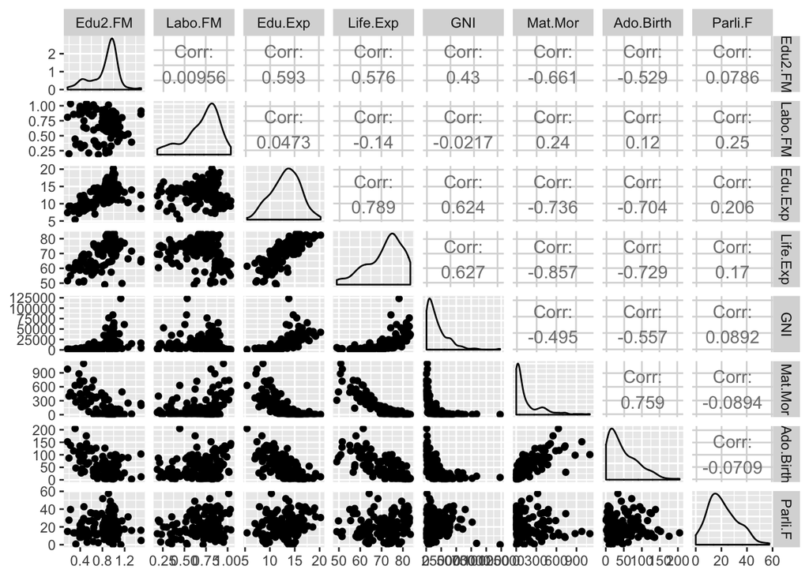

```r
ggpairs(human)
```

The distributions for different variables are different with most of the variables having skewed distribution. For the relationship between variables, some of the clear observations are: There is a strong correlation between the variable pairs:

- Edu.Exp and Life.Exp
- Mat.Mor and Life.Exp
- Mat.Mor and Edu.Exp
- Ado.Birth and Edu.Exp
- Ado.Birth and Mat.Mor

GNI has strongest positive correlation with Edu.Exp and Life.Exp and strongest negative correlation with Ado.Birth and Mat.Mor.

## Part 2 - Perform PCA

```r
pca_human <- prcomp(human)
summary(pca_human)
```

```
## Importance of components:
##                              PC1      PC2   PC3   PC4   PC5   PC6    PC7
## Standard deviation     1.854e+04 185.5219 25.19 11.45 3.766 1.566 0.1912
## Proportion of Variance 9.999e-01   0.0001  0.00  0.00 0.000 0.000 0.0000
## Cumulative Proportion  9.999e-01   1.0000  1.00  1.00 1.000 1.000 1.0000
##                           PC8
## Standard deviation     0.1591
## Proportion of Variance 0.0000
## Cumulative Proportion  1.0000
```

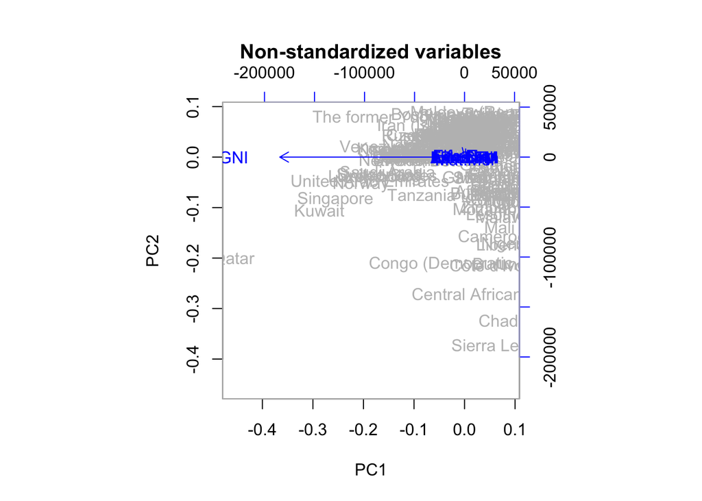

```r
biplot(pca_human, col = c("grey", "blue"), main = "Non-standardized variables")
```

This plot is difficult to understand and makes little sense.

## Part 3 - Perform PCA on standardized data.

```r
human_scaled <- scale(human)
pca_human_scaled <- prcomp(human_scaled)
summary(pca_human_scaled)
```

```
## Importance of components:
##                           PC1    PC2     PC3     PC4     PC5     PC6
## Standard deviation     2.0708 1.1397 0.87505 0.77886 0.66196 0.53631
## Proportion of Variance 0.5361 0.1624 0.09571 0.07583 0.05477 0.03595
## Cumulative Proportion  0.5361 0.6984 0.79413 0.86996 0.92473 0.96069
##                            PC7     PC8
## Standard deviation     0.45900 0.32224
## Proportion of Variance 0.02634 0.01298
## Cumulative Proportion  0.98702 1.00000
```

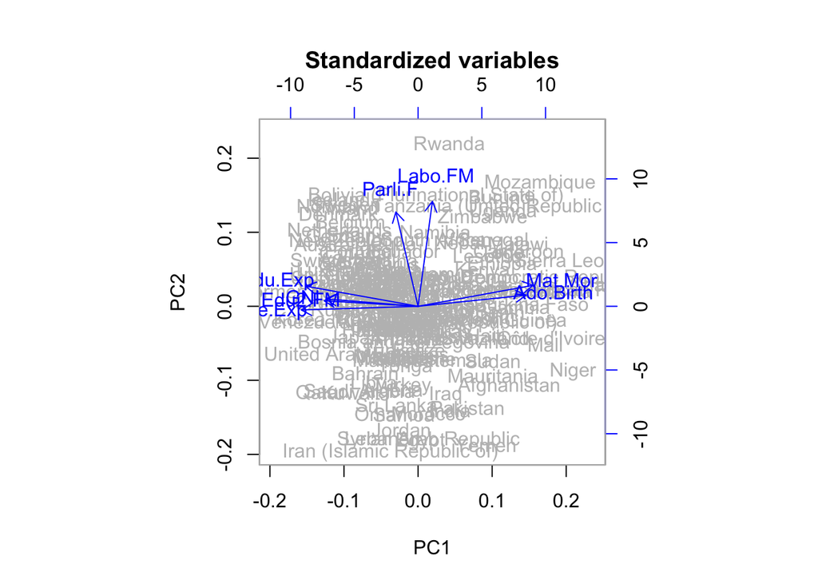

```r
biplot(pca_human_scaled, col = c("grey", "blue"), main = "Standardized variables")
```

## Part 5 - tea dataset from the package Factominer.

```r
library(FactoMineR)
data("tea")
```

```r
dim(tea)
```

```
## [1] 300  36
```

```r
str(tea)
```

```
## 'data.frame':    300 obs. of  36 variables:
##  $ breakfast       : Factor w/ 2 levels "breakfast","Not.breakfast": 1 1 2 2 1 2 1 2 1 1 ...
##  $ tea.time        : Factor w/ 2 levels "Not.tea time",..: 1 1 2 1 1 1 2 2 2 1 ...
##  $ evening         : Factor w/ 2 levels "evening","Not.evening": 2 2 1 2 1 2 2 1 2 1 ...
##  $ lunch           : Factor w/ 2 levels "lunch","Not.lunch": 2 2 2 2 2 2 2 2 2 2 ...
##  $ dinner          : Factor w/ 2 levels "dinner","Not.dinner": 2 2 1 1 2 1 2 2 2 2 ...
##  $ always          : Factor w/ 2 levels "always","Not.always": 2 2 2 2 1 2 2 2 2 2 ...
##  $ home            : Factor w/ 2 levels "home","Not.home": 1 1 1 1 1 1 1 1 1 1 ...
##  $ work            : Factor w/ 2 levels "Not.work","work": 1 1 2 1 1 1 1 1 1 1 ...
##  $ tearoom         : Factor w/ 2 levels "Not.tearoom",..: 1 1 1 1 1 1 1 1 1 2 ...
##  $ friends         : Factor w/ 2 levels "friends","Not.friends": 2 2 1 2 2 2 1 2 2 2 ...
##  $ resto           : Factor w/ 2 levels "Not.resto","resto": 1 1 2 1 1 1 1 1 1 1 ...
##  $ pub             : Factor w/ 2 levels "Not.pub","pub": 1 1 1 1 1 1 1 1 1 1 ...
##  $ Tea             : Factor w/ 3 levels "black","Earl Grey",..: 1 1 2 2 2 2 2 1 2 1 ...
##  $ How             : Factor w/ 4 levels "alone","lemon",..: 1 3 1 1 1 1 1 3 3 1 ...
```

[output cut: 22 more lines]

This data set seems to represent tea consumption patterns of a population. As the structure is complex, let’s select a few variables for analysis:

```r
cols_tea <- c("Tea", "How", "how","sugar", "frequency", "healthy")
tea <- dplyr::select(tea, one_of(cols_tea))
str(tea)
```

```
## 'data.frame':    300 obs. of  6 variables:
##  $ Tea      : Factor w/ 3 levels "black","Earl Grey",..: 1 1 2 2 2 2 2 1 2 1 ...
##  $ How      : Factor w/ 4 levels "alone","lemon",..: 1 3 1 1 1 1 1 3 3 1 ...
##  $ how      : Factor w/ 3 levels "tea bag","tea bag+unpackaged",..: 1 1 1 1 1 1 1 1 2 2 ...
##  $ sugar    : Factor w/ 2 levels "No.sugar","sugar": 2 1 1 2 1 1 1 1 1 1 ...
##  $ frequency: Factor w/ 4 levels "1/day","1 to 2/week",..: 1 1 3 1 3 1 4 2 3 3 ...
##  $ healthy  : Factor w/ 2 levels "healthy","Not.healthy": 1 1 1 1 2 1 1 1 2 1 ...
```

MCA analysis:

```r
mca <- MCA(tea, graph = FALSE)
summary(mca)
```

```
##
## Call:
## MCA(X = tea, graph = FALSE)
##
##
## Eigenvalues
##                        Dim.1   Dim.2   Dim.3   Dim.4   Dim.5   Dim.6
## Variance               0.248   0.220   0.194   0.188   0.174   0.166
## % of var.             12.398  11.013   9.685   9.405   8.684   8.314
## Cumulative % of var.  12.398  23.411  33.096  42.501  51.185  59.499
##                        Dim.7   Dim.8   Dim.9  Dim.10  Dim.11  Dim.12
## Variance               0.164   0.152   0.138   0.132   0.119   0.104
## % of var.              8.222   7.619   6.910   6.608   5.926   5.215
## Cumulative % of var.  67.721  75.340  82.250  88.858  94.785 100.000
##
## Individuals (the 10 first)
##                       Dim.1    ctr   cos2    Dim.2    ctr   cos2    Dim.3
## 1                  | -0.026  0.001  0.001 | -0.314  0.149  0.074 |  0.106
## 2                  |  0.343  0.158  0.064 | -0.669  0.678  0.242 |  0.219
## 3                  |  0.241  0.078  0.076 | -0.159  0.038  0.033 | -0.214
## 4                  | -0.501  0.337  0.273 | -0.444  0.299  0.215 | -0.164
## 5                  | -0.022  0.001  0.000 |  0.244  0.090  0.055 | -0.175
## 6                  | -0.069  0.006  0.005 | -0.420  0.267  0.197 | -0.382
## 7                  | -0.034  0.002  0.001 |  0.371  0.208  0.075 | -0.228
## 8                  |  0.194  0.051  0.015 | -0.197  0.059  0.016 |  0.496
## 9                  |  0.169  0.038  0.015 | -0.032  0.002  0.001 |  0.132
## 10                 |  0.968  1.259  0.660 |  0.076  0.009  0.004 |  0.033
##                       ctr   cos2
## 1                   0.019  0.008 |
## 2                   0.082  0.026 |
## 3                   0.079  0.060 |
## 4                   0.046  0.029 |
## 5                   0.053  0.028 |
## 6                   0.251  0.162 |
## 7                   0.090  0.028 |
## 8                   0.423  0.100 |
## 9                   0.030  0.009 |
## 10                  0.002  0.001 |
##
## Categories (the 10 first)
```

[output cut: 16 more lines]

```
## lemon                0.007   1.425 |   0.832   6.552   0.086   5.058 |
## milk                 0.172  -7.181 |   0.446   3.589   0.053   3.973 |
## other                0.026  -2.813 |   3.048  23.977   0.287   9.268 |
## tea bag              0.127  -6.157 |   0.041   0.082   0.002   0.811 |
## tea bag+unpackaged   0.000  -0.202 |  -0.019   0.009   0.000  -0.219 |
## unpackaged           0.313   9.677 |  -0.145   0.216   0.003  -0.924 |
##
## Categorical variables (eta2)
##                      Dim.1 Dim.2 Dim.3
## Tea                | 0.372 0.033 0.496 |
## How                | 0.145 0.213 0.514 |
## how                | 0.148 0.331 0.004 |
## sugar              | 0.415 0.001 0.082 |
## frequency          | 0.279 0.475 0.064 |
## healthy            | 0.129 0.270 0.002 |
```

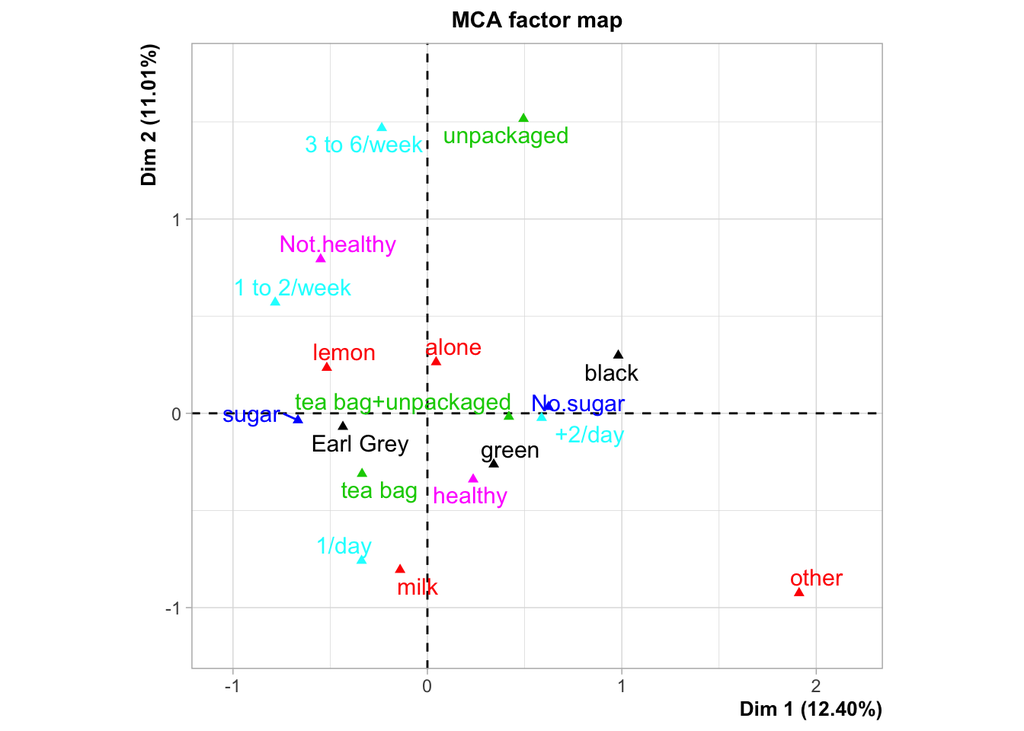

```r
plot(mca, invisible = c("ind"), habillage = "quali")
```

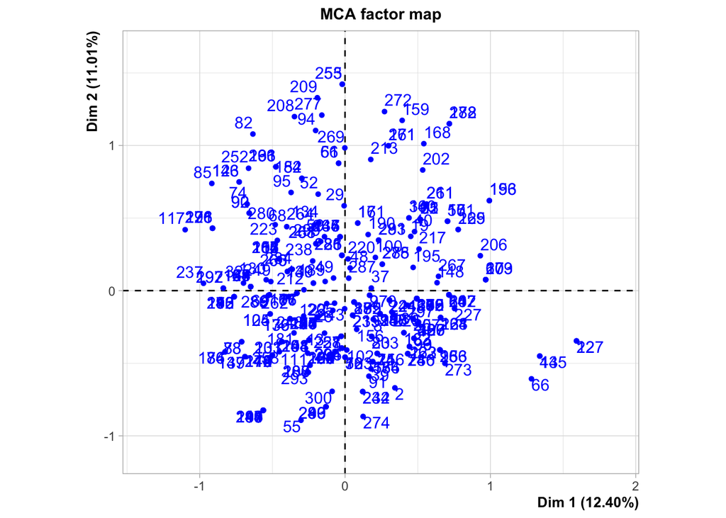

```r
plot(mca, invisible = c("var"), habillage = "quali")
```

Some patterns can be seen here, for example looking at distance between variables we can find following patterns: 1-2 cups/day of tea are healthy, green tea is more healthy compared to black and Early Grey, black tea is mostly taken with no sugar whereas early grey is likely to be taken with sugar, tea with milk is likely to be taken only 1/day and low frequency of tea (1 to 2/week) is closely related to not healthy conditions.